# Ecological Niche Modeling — A Beginner’s Field Guide

A 2-Day Hands-On Workshop with `nicheR` & `bean` 🫛 (two independent modules)

Escobar Lab (DEBY) · Virginia Tech × Faculty of Forestry, Kasetsart University

4–5 July 2026

🟢 **Live mode** — the R code on this page was executed and every figure was generated for real.

**How to read this guide.** This is a *visual textbook*, not just a script. Every step has three parts: **(1)** a plain-English explanation of *why* we do it and *what* each setting means, **(2)** the **R code** itself, and **(3)** the **result you should see**. You can follow along on screen even if R is not on your laptop. When you get back to your own computer, copy the chunks into RStudio and run them for real.

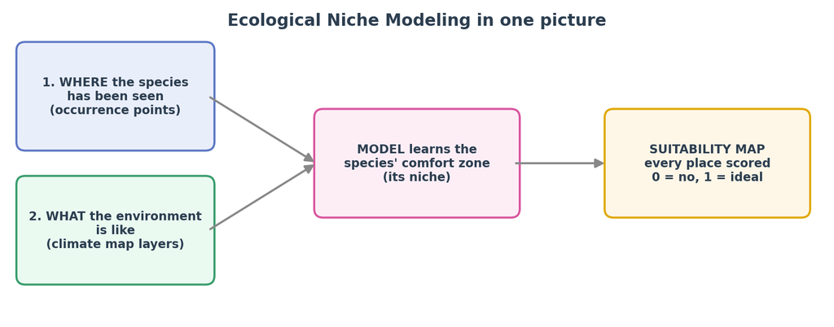

# 1 What is this workshop about?

**Ecological Niche Modeling (ENM)** — also called **Species Distribution Modeling (SDM)** — turns two simple ingredients into a map:

1. **WHERE a species has been seen** — a list of GPS points (*occurrence records*), and
2. **WHAT the environment is like** — climate/soil map layers (*environmental rasters*).

The computer learns the species’ **environmental comfort zone** (its **niche**) and then colours every location on the map with a **suitability** score from **0** (this place is unsuitable) to **1** (ideal).

Over two days we use two small, purpose-built R packages. **They are independent** — you can start with either one.

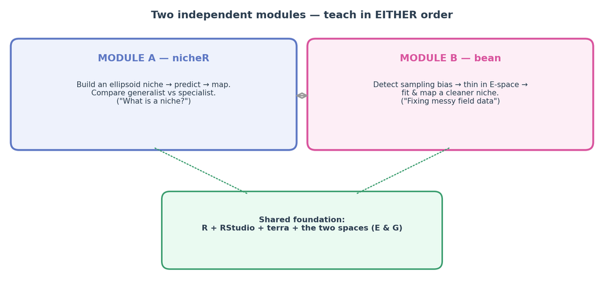

[output not shown]

Both packages come from the Escobar Lab and collaborators, and `bean` is designed to hand its niche objects straight to `nicheR` for mapping.

# 2 Part 0 · Getting started (shared foundation)

*Everything in this part is needed for **both** modules. If your students have never opened R before, spend your first 30 minutes here.*

## 2.1 What are R and RStudio?

- **R** is the *engine* — a free programming language for statistics and data.
- **RStudio** is the *dashboard* you drive it from. When you open RStudio you will see four panes: the **Script editor** (top-left, where you write and save code), the **Console** (bottom-left, where code runs and answers appear), the **Environment** (top-right, the objects you have created), and **Files/Plots/ Help** (bottom-right, where your figures show up).

**How to run a line of code.** Click on a line in the Script editor and press **Ctrl + Enter** (Windows) or **Cmd + Return** (Mac). To run a whole grey code “chunk” in a file like this one, click the little green ▶ arrow at its top-right.

## 2.2 The vocabulary you need (just five words)

| Word | Beginner-friendly meaning |
| --- | --- |
| **Package** | A toolbox of ready-made functions someone else wrote. You *install* it once, then *load* it each session with `library()`. |
| **Function** | A command that does one job. It has a name and takes *arguments* in brackets, e.g. `mean(c(2, 4, 6))`. |
| **Object** | A named box that stores a result, created with `<-` (the arrow). `x <- 5` puts 5 in a box called `x`. |
| **Occurrence** | One record of “the species was seen here” — basically a longitude/latitude pair. |
| **Raster** | A map made of a grid of pixels, where each pixel holds a value (e.g. temperature). A *stack* is several such layers lined up. |

## 2.3 The single most important idea: two “spaces”

Niche modeling constantly flips between **two pictures of the same species**. Understanding this one diagram makes the whole workshop click:

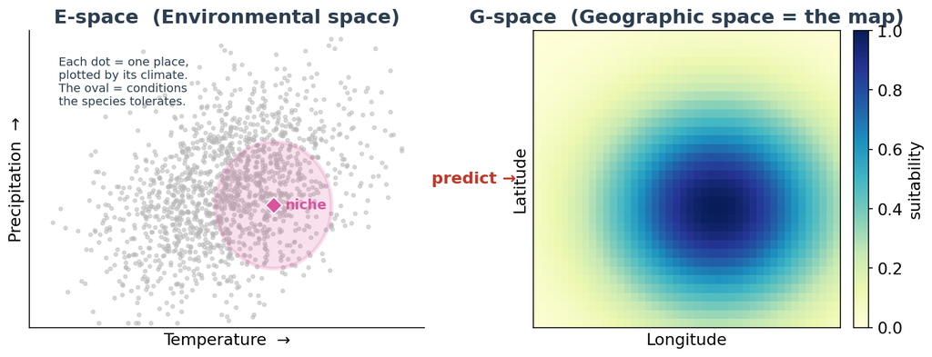

- **E-space (Environmental space).** The axes are environmental variables (e.g. temperature vs. precipitation). Each dot is a *place*, positioned by its climate. A species’ niche is an **ellipse** (an oval cloud) drawn around the conditions it can tolerate.
- **G-space (Geographic space).** The ordinary map, with longitude and latitude. Here we **project** the niche to show *where on Earth* those tolerable conditions actually occur.

The whole game is: **describe the niche in E-space → `predict()` → look at it in G-space.**

## 2.4 Install the software (do this once)

We need R and RStudio (install those from their websites), plus three packages: **`terra`** (spatial/raster tools), **`nicheR`** (Module A), and **`bean`** (Module B).

```r
# Run this block ONCE. It is set to eval=FALSE so it never runs automatically.
# All three packages are on CRAN, so a normal install.packages() is all you need:
install.packages("terra")    # raster / spatial tools
install.packages("nicheR")   # Module A  (Day 1)
install.packages("bean")     # Module B  (Day 2)

# (Tip: you can install all three at once —
#  install.packages(c("terra", "nicheR", "bean")) )
```

Once installed, you only ever *load* them (no re-installing) at the top of a session:

```r
library(terra)     # raster & vector spatial tools (both modules)
library(nicheR)    # ellipsoid niches                (Module A)
library(bean)      # environmental thinning          (Module B)
```

Each module below re-loads exactly what it needs, so you can safely jump straight to whichever one you are teaching.

# 3 Module A · Niche theory & modeling with `nicheR`

**Learning objectives — by the end of Module A you can:**

- explain a niche as an **ellipsoid** living in **E-space**;
- **build** a niche from simple tolerance ranges with `build_ellipsoid()`;
- read a niche’s **volume** as its “breadth” (generalist vs. specialist);
- **`predict()`** suitability across a region and **map** it in G-space;
- state the core result: *a broader niche produces a broader predicted range.*

**Starting the workshop here?** Great — Module A needs nothing from Module B. Just run the *Setup* chunk directly below.

## 3.1 Setup for this module

```r
# Load the tools for Module A (install first if needed — see Part 0).
library(terra)     # for raster maps (G-space)
library(nicheR)    # for ellipsoid niches (E-space)
```

For this workshop we use environmental layers for **Thailand**, so the maps are familiar to everyone in the room:

- **`thai`** — a stack of bioclimatic raster layers for Thailand (our **G-space** map), stored in the workshop’s `inst/` folder. We open it with `terra::rast()`.
- **`back_data`** — a table of background environmental points (our **E-space** “available conditions” cloud), which we build straight from the raster.

```r
# The environmental raster stack for Thailand (Geographic space)
thai <- terra::rast("inst/thai_env.tif")
thai            # 4 layers: bio_1, bio_12, bio_15, bio_4  (88 x 48 cells)
```

```
## class       : SpatRaster
## size        : 88, 48, 4  (nrow, ncol, nlyr)
## resolution  : 0.1666667, 0.1666667  (x, y)
## extent      : 97.5, 105.5, 5.666667, 20.33333  (xmin, xmax, ymin, ymax)
## coord. ref. : lon/lat WGS 84 (EPSG:4326)
## source      : thai_env.tif
## names       :    bio_1, bio_12,    bio_15,     bio_4
## min values  : 20.52728,    806,  37.47298,  53.40236
## max values  : 28.52141,   3802, 108.31721, 336.59756
```

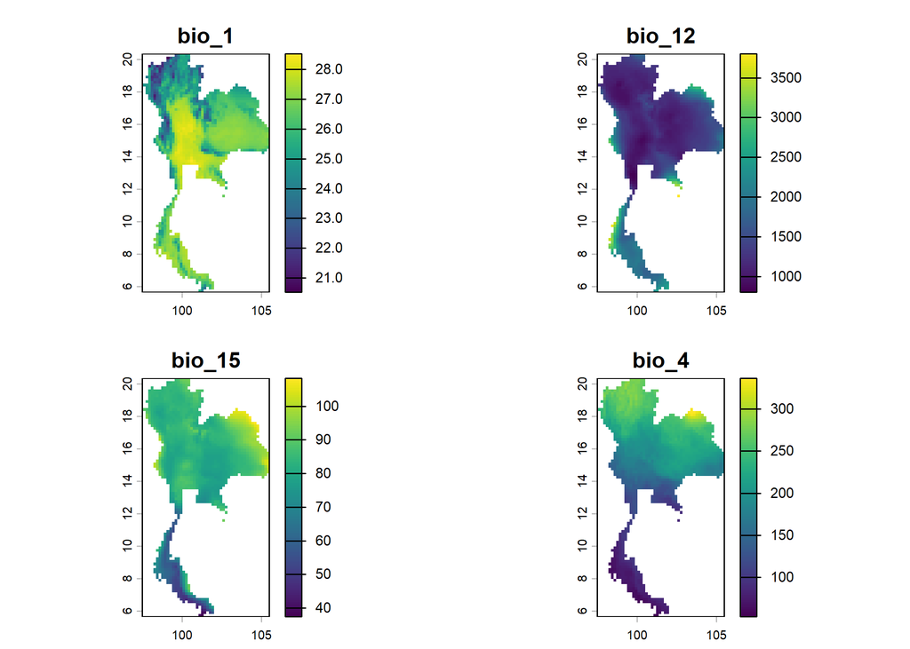

```r
plot(thai)
```

```r
# Build the background environmental cloud from the raster (one row per pixel)
back_data <- as.data.frame(thai, xy = TRUE)
head(back_data)    # columns: x, y, bio_1, bio_12, bio_15, bio_4
```

|  | x | y | bio_1 | bio_12 | bio_15 | bio_4 |
| --- | --- | --- | --- | --- | --- | --- |
| 13 | 99.58333 | 20.25 | 22.63104 | 1444 | 85.71885 | 279.2559 |
| 14 | 99.75000 | 20.25 | 23.88725 | 1558 | 88.32684 | 280.7709 |
| 15 | 99.91667 | 20.25 | 25.36227 | 1733 | 91.82533 | 277.7555 |
| 16 | 100.08333 | 20.25 | 25.48495 | 1756 | 92.60725 | 280.9955 |
| 17 | 100.25000 | 20.25 | 24.65048 | 1709 | 92.03109 | 272.2968 |
| 18 | 100.41667 | 20.25 | 25.24998 | 1751 | 92.80417 | 269.0187 |

To keep things beginner-friendly but realistic, we use **three** variables today: **`bio_1`** (mean annual temperature), **`bio_4`** (temperature seasonality), and **`bio_12`** (annual precipitation). The E-space *plots* show two variables at a time (temperature vs. precipitation); the niche itself lives in all three.

## 3.2 First, just *look* at the environment

Before modeling, always look at the cloud of *available* conditions. We haven’t built a niche yet, so we simply draw the raw background points with base R’s `plot()`. (Once we *do* have an ellipsoid, `nicheR`’s `plot_ellipsoid()` will draw the oval over a cloud exactly like this — see the next E-space figure.)

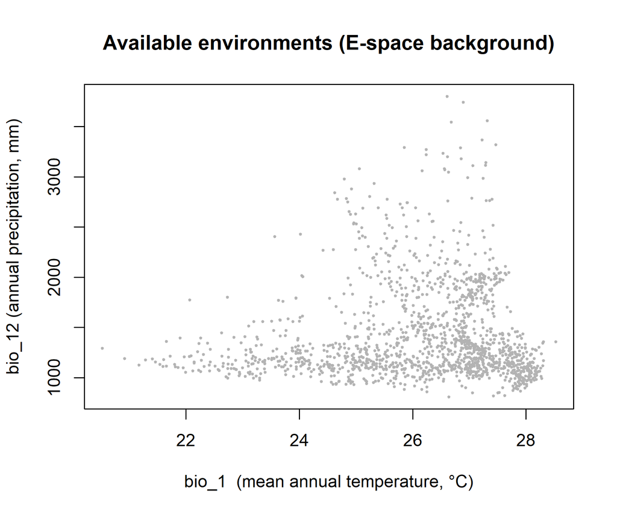

```r
plot(
  back_data[, c("bio_1", "bio_12")],   # just the two variables we use today
  pch  = 20, col = "grey70", cex = 0.5,
  xlab = "bio_1  (mean annual temperature, °C)",
  ylab = "bio_12 (annual precipitation, mm)",
  main = "Available environments (E-space background)"
)
```

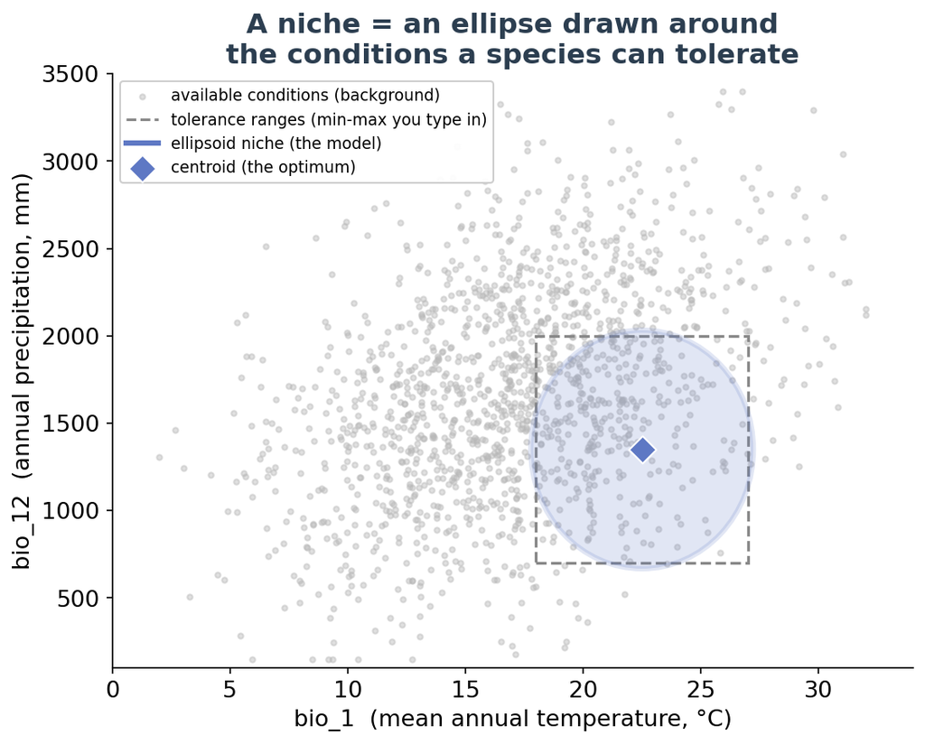